# Problem Set 1: Key to Computational Problems

Amna Javed EC 320: Introduction to Econometrics University of Oregon

Winter 2020

## Preliminaries

```r
library(pacman)
p_load(tidyverse)

election_2016 <- read_csv("election_2016.csv")

# Take a look at the data
election_2016
```

```
## # A tibble: 3,110 x 8
##    stname   fips trump clinton totalvotes white poverty population
##    <chr>   <int> <int>   <int>      <int> <dbl>   <dbl>      <int>
##  1 Alabama  1001 18172    5936      24973  77.1    13.5      55278
##  2 Alabama  1003 72883   18458      95215  85.8    11.7     207509
##  3 Alabama  1005  5454    4871      10469  49.4    29.9      25774
##  4 Alabama  1007  6738    1874       8819  74.7    20.1      22633
##  5 Alabama  1009 22859    2156      25588  90.4    14.1      57562
##  6 Alabama  1011  1140    3530       4710  24.6    32.6      10441
##  7 Alabama  1013  4901    3726       8732  55.1    24.8      19965
##  8 Alabama  1015 32865   13242      47864  75.4    17.1     114980
##  9 Alabama  1017  7843    5784      13900  58.3    19.9      33717
## 10 Alabama  1019  8953    1547      10733  93.5    16.8      25766
## # â¦ with 3,100 more rows
```

## Exercise 1

*Reduce your data set to include only those regions with a population of 50,000 or more.*

```r
# drop observations with population less than 50,000
election_2016 <- election_2016[!(election_2016$population<50000),]
```

## Exercise 2

*Generate new variables that give the percentage of votes cast for each candidate using the* [`mutate`](https://dplyr.tidyverse.org/reference/mutate.html) *function. With these new variables, generate a third variable called* `trump_margin` *that gives Trump’s “margin of victory” in each county. (For counties that Clinton won, the value of* `trump_margin` *will be negative.)*

```r
# generate 3 new variables
# note: the 3rd variable is a function of the first two
election_2016 <- election_2016 %>%
  mutate(trump_pct = trump/totalvotes*100,
         clinton_pct = clinton/totalvotes*100,
         trump_margin = trump_pct - clinton_pct)
```

## Exercise 3

*Produce summary statistics (min, max, mean, median, standard deviation, and the number of observations) for* `trump_margin`, `white`, `poverty`, *and* `population` *using the* [`summarize`](https://dplyr.tidyverse.org/reference/summarise.html) *function.*

You can use one of two approaches.

**Approach 1:** Brute force.

```r
# the "variable" variable is for making one nice-looking table later
trump_margin_summary <- election_2016 %>%
  summarize(variable = "trump_margin",
            min = min(trump_margin),
            max = max(trump_margin),
            mean = mean(trump_margin),
            median = median(trump_margin),
            sd = sd(trump_margin),
            n = n())

white_summary <- election_2016 %>%
  summarize(variable = "white",
            min = min(white),
            max = max(white),
            mean = mean(white),
            median = median(white),
            sd = sd(white),
            n = n())

poverty_summary <- election_2016 %>%
  summarize(variable = "poverty",
            min = min(poverty),
            max = max(poverty),
            mean = mean(poverty),
            median = median(poverty),
            sd = sd(poverty),
            n = n())

population_summary <- election_2016 %>%
  summarize(variable = "population",
            min = min(population),
            max = max(population),
            mean = mean(population),
            median = median(population),
            sd = sd(population),
            n = n())

# generate a nice table of summary stats (bind_rows "stacks" tibbles)
summary_stats <- bind_rows(trump_margin_summary,
                           white_summary,
                           poverty_summary,
                           population_summary)

# look at your stats
summary_stats
```

```
## # A tibble: 4 x 7
##   variable          min        max     mean   median        sd     n
##   <chr>           <dbl>      <dbl>    <dbl>    <dbl>     <dbl> <int>
## 1 trump_margin   -86.8        80.9     14.1     18.4     30.2    979
## 2 white            3.05       98.0     75.4     80.6     18.3    979
## 3 poverty          3.39       39.9     14.0     13.6      5.03   979
## 4 population   50058    10150558   288989.  128206   548988.     979
```

After doing this, you might want to remove clutter from your global environment by running `rm(trump_margin_summary, white_summary, poverty_summary, population_summary)`. The `rm()` function removes unnecessary objects from the global environment. You don’t have to do this, but keeping a relatively clean global environment can make your life easier.

**Approach 2:** Define and use a function.

```r
# it's a good idea to define functions for repetitive tasks
summary_fun <- function(data, x){
  data %>%
    summarize(min = min(x),
              max = max(x),
              mean = mean(x),
              median = median(x),
              sd = sd(x),
              n = n()
              )
}

# generate a nice table of summary stats (bind_rows "stacks" tibbles)
summary_stats <- bind_rows(
  summary_fun(election_2016, election_2016$trump_margin) %>%
    mutate(variable = "trump_margin"),
  summary_fun(election_2016, election_2016$white) %>%
    mutate(variable = "white"),
  summary_fun(election_2016, election_2016$poverty) %>%
    mutate(variable = "poverty"),
  summary_fun(election_2016, election_2016$population) %>%
    mutate(variable = "population")
)

# look at your stats
summary_stats
```

```
## # A tibble: 4 x 7
##        min        max     mean   median        sd     n variable
##      <dbl>      <dbl>    <dbl>    <dbl>     <dbl> <int> <chr>
## 1   -86.8        80.9     14.1     18.4     30.2    979 trump_margin
## 2     3.05       98.0     75.4     80.6     18.3    979 white
## 3     3.39       39.9     14.0     13.6      5.03   979 poverty
## 4 50058    10150558   288989.  128206   548988.     979 population
```

### Part A

*What is Trump’s average vote margin?*

```r
election_2016 %>%
  summarize(mean = mean(trump_margin))
```

```
## # A tibble: 1 x 1
##    mean
##   <dbl>
## 1  14.1
```

Trump’s average vote margin is approximately 14.1 percent.

### Part B

*What is the median poverty rate?*

```r
election_2016 %>%
  summarize(median = median(poverty))
```

```
## # A tibble: 1 x 1
##   median
##    <dbl>
## 1   13.6
```

The median poverty rate is approximately 13.6 percent.

### Part C

*How many people live in the least populous county? How many live in the most populous county?*

```r
election_2016 %>%
  summarize(min = min(population),
            max = max(population))
```

```
## # A tibble: 1 x 2
##     min      max
##   <int>    <int>
## 1 50058 10150558
```

10,150,558 people live in the most populous county (in case you were wondering, it’s Los Angeles County, CA). 50,058 people live in the least populous county in our data. Note that we reduced our data by dropping counties with a population less than 50,000 people so this is not the actual least populated county from the 2016 election.

## Exercise 4

*Create a histogram of Trump’s margin of victory. Which candidate won more counties? Is it necessarily the case that this candidate won more votes nationally? Hint: Look at a histogram of county population, too.*

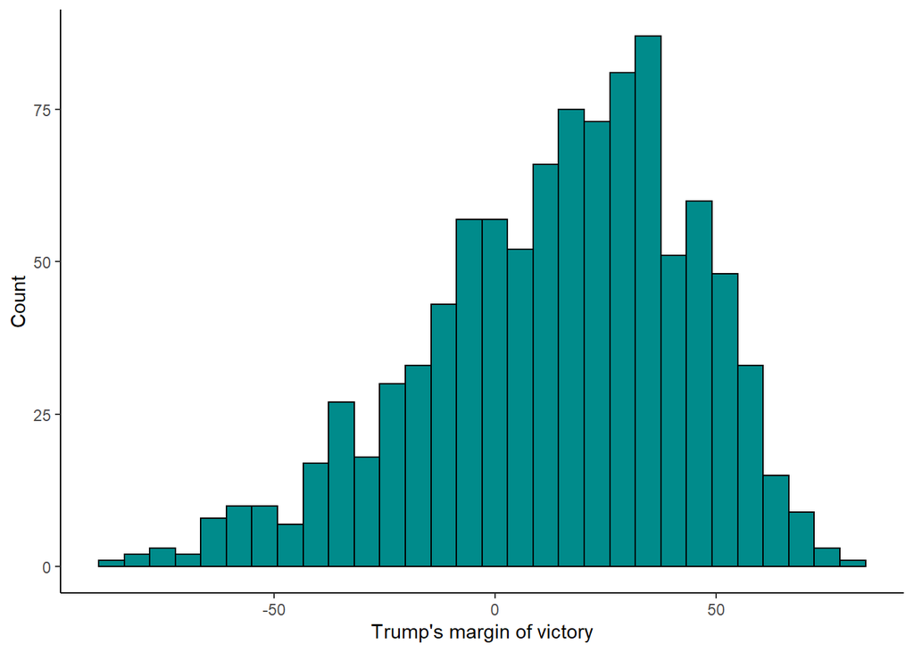

```r
gg <- election_2016 %>%
  ggplot(aes(x = trump_margin)) +
  geom_histogram(color="black", fill="cyan4")

# The code below improves the visual aspects of the graph
gg <- gg +
  theme_classic() + # cleans up the background
  labs(x = "Trump's margin of victory", y = "Count") # change the labels

gg
```

While Trump appears to have won most counties, many of those counties have relatively small populations (see below). It happens to be the case that Clinton won more votes nationally.

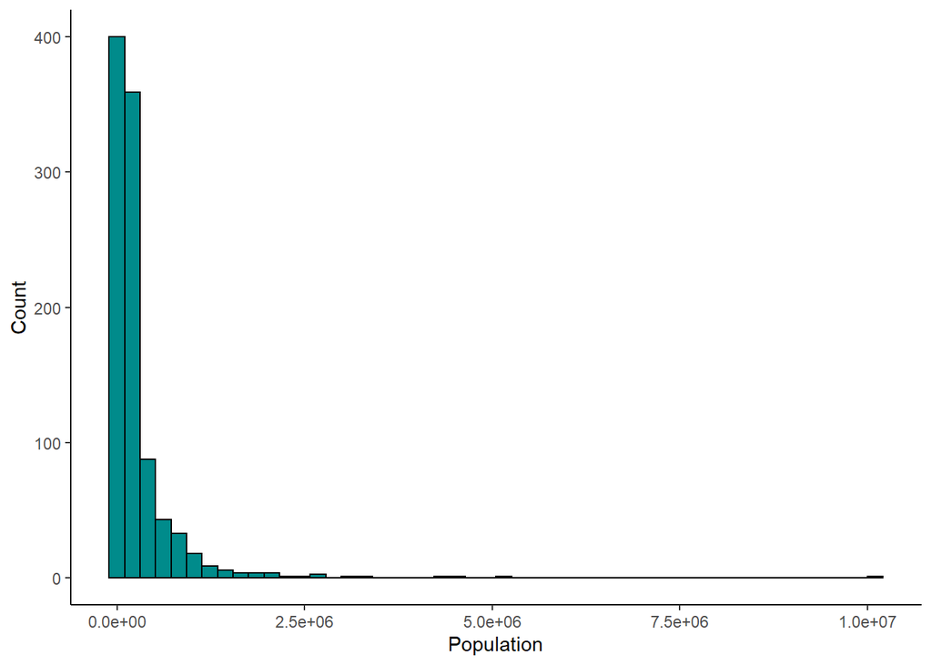

```r
gg_pop <- election_2016 %>%
  ggplot(aes(x = population)) +
  geom_histogram(bins = 50, color="black", fill="cyan4")

# The code below improves the visual aspects of the graph
gg_pop  <- gg_pop +
  theme_classic() + # cleans up the background
  labs(x = "Population", y = "Count") # change the labels

gg_pop
```

## Exercise 5

*Create a scatter plot with* `trump_margin` *on the* $Y$*-axis and* `poverty` *on the* $X$*-axis. Does support for Trump appear positively or negatively correlated with poverty rates? Use the* [`cor`](https://www.rdocumentation.org/packages/stats/versions/3.6.1/topics/cor) *function to calculate the correlation coefficient. Interpret your result.*

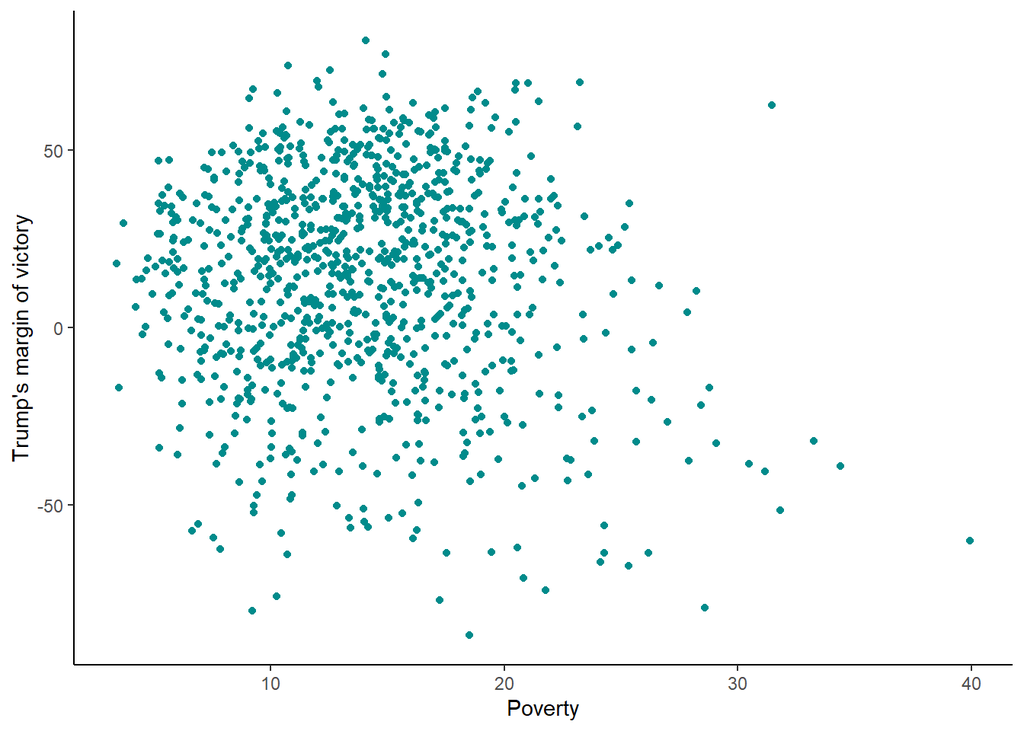

```r
gg_pov <- election_2016 %>%
  ggplot(aes(x = poverty, y = trump_margin)) +
  geom_point(color = "cyan4")

# The code below improves the visual aspects of the graph
gg_pov <- gg_pov +
  theme_classic() + # cleans up the background
  labs(y = "Trump's margin of victory", x = "Poverty") # change the labels

gg_pov
```

By looking at the scatter plot alone, it is hard to tell whether poverty and support for Trump are correlated. The next step is to estimate the correlation coefficient:

```r
cor(election_2016$poverty, election_2016$trump_margin)
```

```
## [1] -0.08732758
```

The correlation coefficient of -0.09 tells us that there is a negative, albeit weak, correlation between poverty rates and support for Trump in our sample of counties.

## Exercise 6

*Create a scatter plot with* `trump_margin` *on the* $Y$*-axis and* `poverty` *on the* $X$*-axis. Does support for Trump appear positively or negatively correlated with the percentage of white voters? Use the* `cor` *function to calculate the correlation coefficient. Interpret your result.*

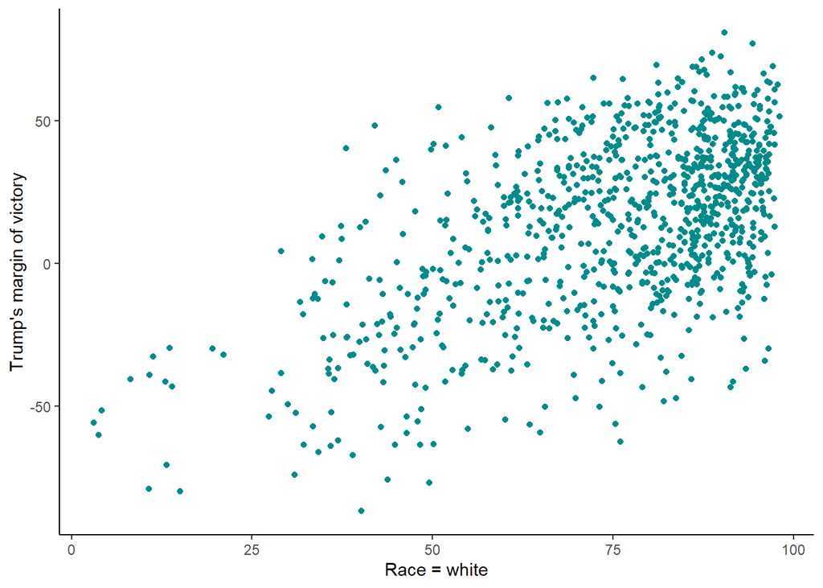

```r
gg_pov <- election_2016 %>%
  ggplot(aes(x = white, y = trump_margin)) +
  geom_point(color = "cyan4")

gg_pov <- gg_pov +
  theme_classic() + # cleans up the background
  labs(y = "Trump's margin of victory", x = "Race = white") # change the labels

gg_pov
```

The fraction of white voters appears positively correlated with Trump’s vote margin. To verify, we can once again estimate the correlation coefficient:

```r
cor(election_2016$white, election_2016$trump_margin)
```

```
## [1] 0.5588337
```

The correlation coefficient of 0.56 verifies that there is a positive correlation between the fraction of white voters in a county and support for Trump.

## Exercise 7

*Using* [`group_by`](https://dplyr.tidyverse.org/reference/group_by.html) *and* `summarize`, *aggregate the county-level data on* `white`, `poverty`, *and* `population` *to the state level. The first two variables are rates. To obtain accurate state-level rates, you need to account for differences in population across counties. You can do this by using the* [`weighted.mean`](https://www.rdocumentation.org/packages/stats/versions/3.6.1/topics/weighted.mean) *function inside* `summarize`. *For population, you can use the* `sum` *function. Your new* [`tibble`](https://tibble.tidyverse.org) *should have 50 rows.*

```r
# aggregate to the state level
state_data <- election_2016 %>%
  group_by(stname) %>%
  summarize(poverty = weighted.mean(x = poverty, w = population),
            white = weighted.mean(x = white, w = population),
            population = sum(population))

state_data
```

```
## # A tibble: 50 x 4
##    stname               poverty white population
##    <chr>                  <dbl> <dbl>      <int>
##  1 Alabama                15.9   69.2    3958271
##  2 Arizona                16.3   61.0    6794654
##  3 Arkansas               15.2   75.3    1798268
##  4 California             14.3   41.8   38967924
##  5 Colorado               10.7   72.0    4917958
##  6 Connecticut             9.86  71.2    3587685
##  7 Delaware               11.8   66.8     952698
##  8 District of Columbia   18.5   40.1     684336
##  9 Florida                14.6   57.6   20014110
## 10 Georgia                14.9   53.1    8113330
## # â¦ with 40 more rows
```

## Exercise 8

*Using the state-level data, create a scatter plot with* `poverty` *on the* $Y$*-axis and* `white` *on the* $X$*-axis. To illustrate differences in population across states, vary the size of each point by population. You can this by including* `size = population` *in the* [`aes`](https://ggplot2.tidyverse.org/reference/aes.html) *function of* [`ggplot`](https://ggplot2.tidyverse.org/reference/ggplot.html). *Describe any patterns you see.*

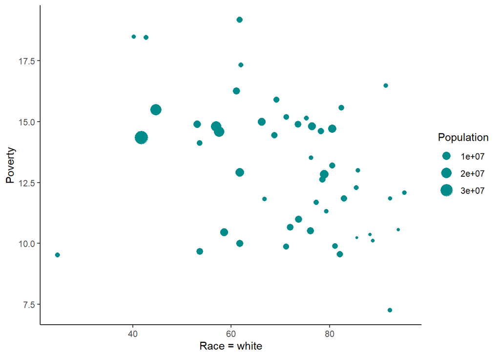

```r
# a "weighted" scatterplot
s_pov <- state_data %>%
  ggplot(aes(x = white, y = poverty, size = population)) +
  geom_point(color = "cyan4")

s_pov <- s_pov +
  theme_classic() + # cleans up the background
  labs(y = "Poverty", x = "Race = white", size = "Population") # change the labels
s_pov
```